# Practical Machine Learning - Peer Assessment

CSchnider

March 22th, 2015

# Background

Using devices such as Jawbone Up, Nike FuelBand, and Fitbit it is now possible to collect a large amount of data about personal activity relatively inexpensively. These type of devices are part of the quantified self movement - a group of enthusiasts who take measurements about themselves regularly to improve their health, to find patterns in their behavior, or because they are tech geeks. One thing that people regularly do is quantify how much of a particular activity they do, but they rarely quantify how well they do it. In this project, your goal will be to use data from accelerometers on the belt, forearm, arm, and dumbell of 6 participants. They were asked to perform barbell lifts correctly and incorrectly in 5 different ways. More information is available from the website here: http://groupware.les.inf.puc-rio.br/har (see the section on the Weight Lifting Exercise Dataset).

The data for this project come from this source: http://groupware.les.inf.puc-rio.br/har

# Loading and preprocessing the data

## Set working directory

```r
setwd("~/R/Coursera/05 Machine Learning")
```

## Download data

```r
if (!file.exists("./pml-training.csv")) {
    download.file("https://d396qusza40orc.cloudfront.net/predmachlearn/pml-training.csv",
        destfile = "./pml-training.csv")
}
if (!file.exists("./pml-testing.csv")) {
    download.file("https://d396qusza40orc.cloudfront.net/predmachlearn/pml-testing.csv",
        destfile = "./pml-testing.csv")
}
```

## Read CSV files

```r
training <- read.csv("pml-training.csv", na.strings=c("", "NA","#DIV/0!"))
testing <- read.csv("pml-testing.csv", na.strings=c("", "NA","#DIV/0!"))
```

# Descriptive Analysis of Dataset

## Counts

Count of rows:

```r
nrow(training)
```

```
## [1] 19622
```

Count of columns:

```r
ncol(training)
```

```
## [1] 160
```

Count of complete records:

```r
sum(complete.cases(training))
```

```
## [1] 0
```

What we can see here is there are many incomplete records.

Number of NAs per column:

```r
x<-colSums(is.na(training))
labels(x[x<=0])
```

```
##  [1] "X"                    "user_name"            "raw_timestamp_part_1"
##  [4] "raw_timestamp_part_2" "cvtd_timestamp"       "new_window"
##  [7] "num_window"           "roll_belt"            "pitch_belt"
## [10] "yaw_belt"             "total_accel_belt"     "gyros_belt_x"
## [13] "gyros_belt_y"         "gyros_belt_z"         "accel_belt_x"
## [16] "accel_belt_y"         "accel_belt_z"         "magnet_belt_x"
## [19] "magnet_belt_y"        "magnet_belt_z"        "roll_arm"
## [22] "pitch_arm"            "yaw_arm"              "total_accel_arm"
## [25] "gyros_arm_x"          "gyros_arm_y"          "gyros_arm_z"
## [28] "accel_arm_x"          "accel_arm_y"          "accel_arm_z"
## [31] "magnet_arm_x"         "magnet_arm_y"         "magnet_arm_z"
## [34] "roll_dumbbell"        "pitch_dumbbell"       "yaw_dumbbell"
## [37] "total_accel_dumbbell" "gyros_dumbbell_x"     "gyros_dumbbell_y"
## [40] "gyros_dumbbell_z"     "accel_dumbbell_x"     "accel_dumbbell_y"
## [43] "accel_dumbbell_z"     "magnet_dumbbell_x"    "magnet_dumbbell_y"
## [46] "magnet_dumbbell_z"    "roll_forearm"         "pitch_forearm"
## [49] "yaw_forearm"          "total_accel_forearm"  "gyros_forearm_x"
## [52] "gyros_forearm_y"      "gyros_forearm_z"      "accel_forearm_x"
## [55] "accel_forearm_y"      "accel_forearm_z"      "magnet_forearm_x"
## [58] "magnet_forearm_y"     "magnet_forearm_z"     "classe"
```

There a re many columns with the same amount of missing data. Probably these variables should be ignored. Otherwise these variables could be good indicators for as specific class. Let’s try to ignore these variables in the first try. If the prediction is not as good as it should be, we’ll need to include them again.

Distribution of Classes:

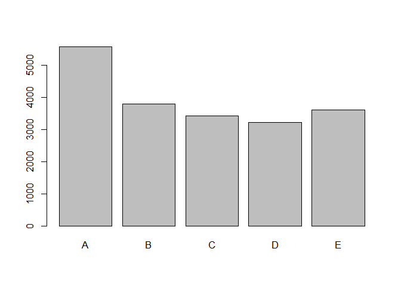

```r
library(plyr)
classe_freq<-count(training, "classe")
barplot(classe_freq$freq,names.arg=classe_freq$classe)
```

Description of Classes:

- A: exactly according to the specification
- B: throwing the elbows to the front
- C: lifting the dumbbell only halfway
- D: lowering the dumbbell only halfway
- E: throwing the hips to the front

Read more: http://groupware.les.inf.puc-rio.br/har#dataset#ixzz3UzyMCtX9

## Overview/Structure of Datset

```r
str(training)
```

```
## 'data.frame':    19622 obs. of  160 variables:
##  $ X                       : int  1 2 3 4 5 6 7 8 9 10 ...
##  $ user_name               : Factor w/ 6 levels "adelmo","carlitos",..: 2 2 2 2 2 2 2 2 2 2 ...
##  $ raw_timestamp_part_1    : int  1323084231 1323084231 1323084231 1323084232 1323084232 1323084232 1323084232 1323084232 1323084232 1323084232 ...
##  $ raw_timestamp_part_2    : int  788290 808298 820366 120339 196328 304277 368296 440390 484323 484434 ...
##  $ cvtd_timestamp          : Factor w/ 20 levels "02/12/2011 13:32",..: 9 9 9 9 9 9 9 9 9 9 ...
##  $ new_window              : Factor w/ 2 levels "no","yes": 1 1 1 1 1 1 1 1 1 1 ...
##  $ num_window              : int  11 11 11 12 12 12 12 12 12 12 ...
##  $ roll_belt               : num  1.41 1.41 1.42 1.48 1.48 1.45 1.42 1.42 1.43 1.45 ...
##  $ pitch_belt              : num  8.07 8.07 8.07 8.05 8.07 8.06 8.09 8.13 8.16 8.17 ...
##  $ yaw_belt                : num  -94.4 -94.4 -94.4 -94.4 -94.4 -94.4 -94.4 -94.4 -94.4 -94.4 ...
##  $ total_accel_belt        : int  3 3 3 3 3 3 3 3 3 3 ...
##  $ kurtosis_roll_belt      : num  NA NA NA NA NA NA NA NA NA NA ...
##  $ kurtosis_picth_belt     : num  NA NA NA NA NA NA NA NA NA NA ...
##  $ kurtosis_yaw_belt       : logi  NA NA NA NA NA NA ...
```

[output cut: 86 more lines]

## Selection of variables

We’ll keep only the variables without missing values and exclude user metadata in columns 1-7 (name, timestamps, etc.).

```r
col_selection<-colnames(training[,colSums(is.na(training))==0])
col_selection<-col_selection[-(1:7)]
col_selection
```

```
##  [1] "roll_belt"            "pitch_belt"           "yaw_belt"
##  [4] "total_accel_belt"     "gyros_belt_x"         "gyros_belt_y"
##  [7] "gyros_belt_z"         "accel_belt_x"         "accel_belt_y"
## [10] "accel_belt_z"         "magnet_belt_x"        "magnet_belt_y"
## [13] "magnet_belt_z"        "roll_arm"             "pitch_arm"
## [16] "yaw_arm"              "total_accel_arm"      "gyros_arm_x"
## [19] "gyros_arm_y"          "gyros_arm_z"          "accel_arm_x"
## [22] "accel_arm_y"          "accel_arm_z"          "magnet_arm_x"
## [25] "magnet_arm_y"         "magnet_arm_z"         "roll_dumbbell"
## [28] "pitch_dumbbell"       "yaw_dumbbell"         "total_accel_dumbbell"
## [31] "gyros_dumbbell_x"     "gyros_dumbbell_y"     "gyros_dumbbell_z"
## [34] "accel_dumbbell_x"     "accel_dumbbell_y"     "accel_dumbbell_z"
## [37] "magnet_dumbbell_x"    "magnet_dumbbell_y"    "magnet_dumbbell_z"
## [40] "roll_forearm"         "pitch_forearm"        "yaw_forearm"
## [43] "total_accel_forearm"  "gyros_forearm_x"      "gyros_forearm_y"
## [46] "gyros_forearm_z"      "accel_forearm_x"      "accel_forearm_y"
## [49] "accel_forearm_z"      "magnet_forearm_x"     "magnet_forearm_y"
## [52] "magnet_forearm_z"     "classe"
```

Exclude unwanted variables from training dataset:

```r
training_red<-training[,col_selection]
```

Count of rows:

```r
nrow(training_red)
```

```
## [1] 19622
```

Count of columns:

```r
ncol(training_red)
```

```
## [1] 53
```

Count of complete records:

```r
sum(complete.cases(training_red))
```

```
## [1] 19622
```

## Predictive Model

Let’s use the random forest algorithm for an initial attempt at building a predictive model.

Load libraries and set the seed:

```r
library(randomForest)
library(caret)
set.seed(123)
```

Let’s train the predictive model:

```r
model <- randomForest(classe ~ ., training_red, ntree = 1024)
```

```r
model
```

```
##
## Call:
##  randomForest(formula = classe ~ ., data = training_red, ntree = 1024)
##                Type of random forest: classification
##                      Number of trees: 1024
## No. of variables tried at each split: 7
##
##         OOB estimate of  error rate: 0.26%
## Confusion matrix:
##      A    B    C    D    E  class.error
## A 5578    2    0    0    0 0.0003584229
## B    9 3785    3    0    0 0.0031603898
## C    0    8 3413    1    0 0.0026300409
## D    0    0   20 3194    2 0.0068407960
## E    0    0    1    5 3601 0.0016634322
```

```r
model$confusion
```

```
##      A    B    C    D    E  class.error
## A 5578    2    0    0    0 0.0003584229
## B    9 3785    3    0    0 0.0031603898
## C    0    8 3413    1    0 0.0026300409
## D    0    0   20 3194    2 0.0068407960
## E    0    0    1    5 3601 0.0016634322
```

With an error rate 0f 0.26% the result looks very good.

Let’s have a look at the importance of the variables:

```r
varImp(model)
```

```
##                         Overall
## roll_belt            1281.79078
## pitch_belt            705.56031
## yaw_belt              919.20651
## total_accel_belt      211.59982
## gyros_belt_x           95.30189
## gyros_belt_y          110.59950
## gyros_belt_z          302.98799
## accel_belt_x          111.94243
## accel_belt_y          117.27886
## accel_belt_z          375.74666
## magnet_belt_x         242.26276
## magnet_belt_y         396.74206
## magnet_belt_z         398.62285
## roll_arm              333.43770
## pitch_arm             174.54614
## yaw_arm               238.43954
## total_accel_arm        98.27844
## gyros_arm_x           130.73229
## gyros_arm_y           137.31298
## gyros_arm_z            56.79251
## accel_arm_x           244.82426
## accel_arm_y           158.55362
## accel_arm_z           130.04751
## magnet_arm_x          256.74348
## magnet_arm_y          232.63297
## magnet_arm_z          188.57313
## roll_dumbbell         407.43973
## pitch_dumbbell        170.57700
## yaw_dumbbell          251.27030
## total_accel_dumbbell  270.46021
## gyros_dumbbell_x      123.80499
## gyros_dumbbell_y      253.03523
## gyros_dumbbell_z       79.90055
## accel_dumbbell_x      249.90100
## accel_dumbbell_y      409.65870
## accel_dumbbell_z      330.84678
## magnet_dumbbell_x     485.32175
## magnet_dumbbell_y     690.49395
## magnet_dumbbell_z     745.32295
## roll_forearm          617.56612
## pitch_forearm         764.71671
## yaw_forearm           174.58616
## total_accel_forearm   109.33734
## gyros_forearm_x        74.63258
## gyros_forearm_y       125.82452
## gyros_forearm_z        81.30220
## accel_forearm_x       330.82075
## accel_forearm_y       140.27966
## accel_forearm_z       252.64798
## magnet_forearm_x      218.35041
## magnet_forearm_y      221.16134
## magnet_forearm_z      282.69730
```

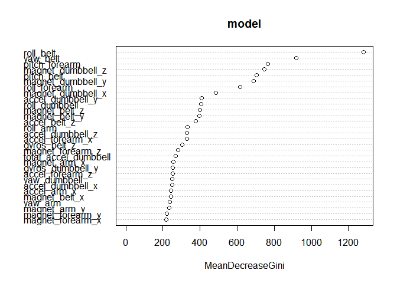

```r
varImpPlot(model,)
```

# Pedict classes for Testing dataset

Use model to predict classes:

```r
answers<-predict(model, testing)
answers
```

```
##  1  2  3  4  5  6  7  8  9 10 11 12 13 14 15 16 17 18 19 20
##  B  A  B  A  A  E  D  B  A  A  B  C  B  A  E  E  A  B  B  B
## Levels: A B C D E
```

Create the files for the validation:

```r
pml_write_files = function(x){
          n = length(x)
          for(i in 1:n){
                    filename = paste0("problem_id_",i,".txt")
                    write.table(x[i],file=filename,quote=FALSE,row.names=FALSE,col.names=FALSE)
          }
}

pml_write_files(answers)
```

The model predicts all test records correctly. There’s no need to optimize the model.

## References

http://groupware.les.inf.puc-rio.br/har